# Tarea 2 Big Data-Sigma

Shanthal Chavarría

2021-07-19

# 1. **[30 puntos]** Usando la tabla de datos `ChurnTelecom6k.csv` realice lo siguiente:

```r
library(readr)

datos <- read.table("Datos Tarea/ChurnTelecom6K.csv", sep = ",", dec = ".", header = TRUE,
    stringsAsFactors = TRUE)
```

## a) Utilizando la función `lapply` cree para el modelo de árboles, con sus parámetros por defecto, una validación cruzada k-folds usando 10 grupos (sin repeticiones).

```r
library(traineR)
library(caret)
library(purrr)

version.lapply <- function(datos) {
    n <- dim(datos)[1]

    grupos <- createFolds(1:n, 10)


    resultados <- lapply(grupos, function(muestra) {

        ttesting <- datos[muestra, ]
        taprendizaje <- datos[-muestra, ]

        modelo <- train.rpart(Churn ~ ., taprendizaje)

        prediccion <- predict(modelo, ttesting)

        MC <- confusion.matrix(ttesting, prediccion)

        error <- (1 - sum(diag(MC))/sum(MC)) * 100
    })

    resultados

    return(reduce(resultados, sum)/10)

}

version.lapply(datos)
```

```
[1] 28.03333
```

## b) Utilizando el paquete `snow` y la función `clusterApply`, adapte su código anterior para que este se ejecute en paralelo.

```r
library(snow)

# Creación de los nodos
version.snow <- function(datos) {

    peones <- parallel::detectCores()
    clp <- makeCluster(peones, type = "SOCK")

    # Constructor del cluster
    ignore <- clusterExport(clp, "datos")


    numero.filas <- nrow(datos)
    cantidad.grupos <- 10

    grupos <- createFolds(1:numero.filas, cantidad.grupos)  # Crea los 10 grupos




    resultado <- clusterApply(clp, grupos, function(muestra) {

        library(traineR)

        ttesting <- datos[muestra, ]
        taprendizaje <- datos[-muestra, ]

        modelo <- train.rpart(Churn ~ ., taprendizaje)

        prediccion <- predict(modelo, ttesting)

        MC <- confusion.matrix(ttesting, prediccion)

        # Cálculo del ERROR
        error <- (1 - (sum(diag(MC)))/sum(MC)) * 100


    })
    resultado

    return(reduce(resultado, sum)/10)
}

version.snow(datos)
```

```
[1] 28.03333
```

## c) Usando la función `mark` del paquete `bench` compare el rendimiento de ambas versiones, en este caso utilizando el parámetro `iterations = 2`.

```r
library(bench)

mark("sequencial" = version.lapply(datos),

     "paralelo" = version.snow(datos), iterations = 2, relative = T, check = F)
```

```
# A tibble: 2 x 6
  expression   min median `itr/sec` mem_alloc `gc/sec`
  <bch:expr> <dbl>  <dbl>     <dbl>     <dbl>    <dbl>
1 sequencial  2.70   2.74      1        4193.      Inf
2 paralelo    1      1         2.74        1       NaN
```

# 2. **[40 puntos]** Para este ejercicio vamos a usar la tabla de datos `PostUpvotes.csv`, la cual contiene información de posts publicados en una red social. Esta tabla de datos contiene 6000 posts y 4 variables numéricas que los describen.

```r
datos <- read.table("Datos Tarea/PostUpvotes.csv", sep = ";", dec = ".", header = TRUE,
    stringsAsFactors = TRUE)
```

Realice lo siguiente:

## a) Usando `clusterApply` y la función `hclust` construya una función que reciba una tabla de datos y retorne una lista con 8 dendrogramas con los métodos `ward.D`, `ward.D2`, `single`, `complete`, `average`, `mcquitty`, `median` y `centroid`, luego gráfique los cada uno de los dendrogramas.

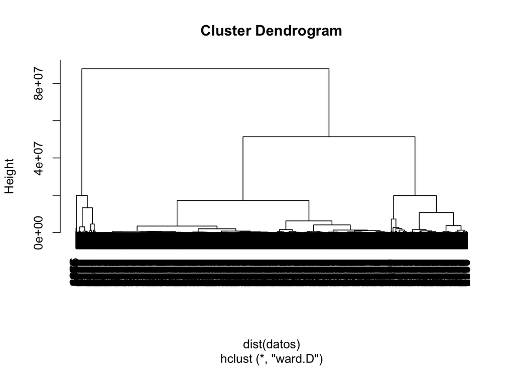

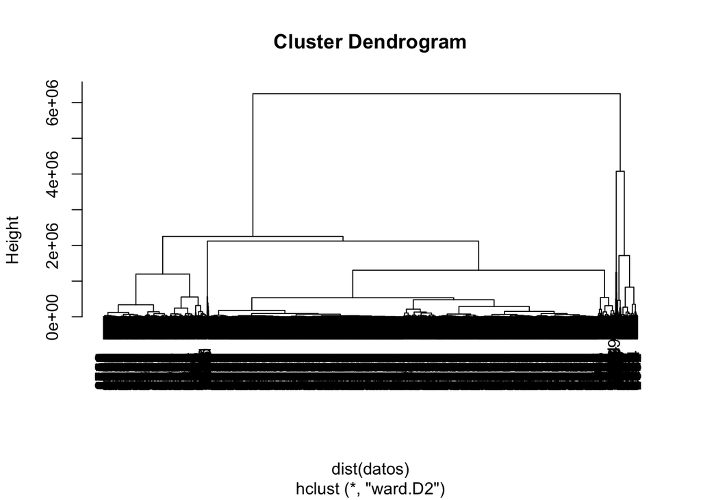

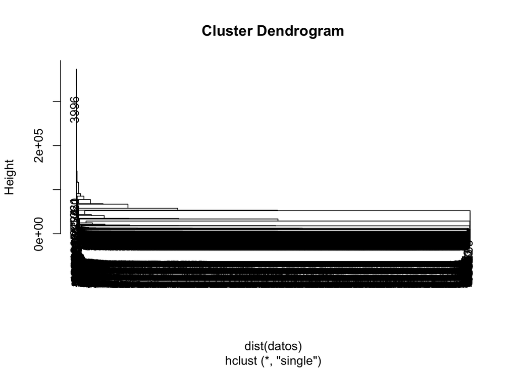

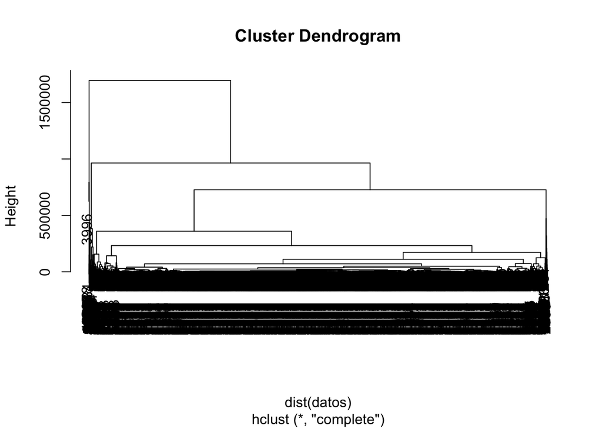

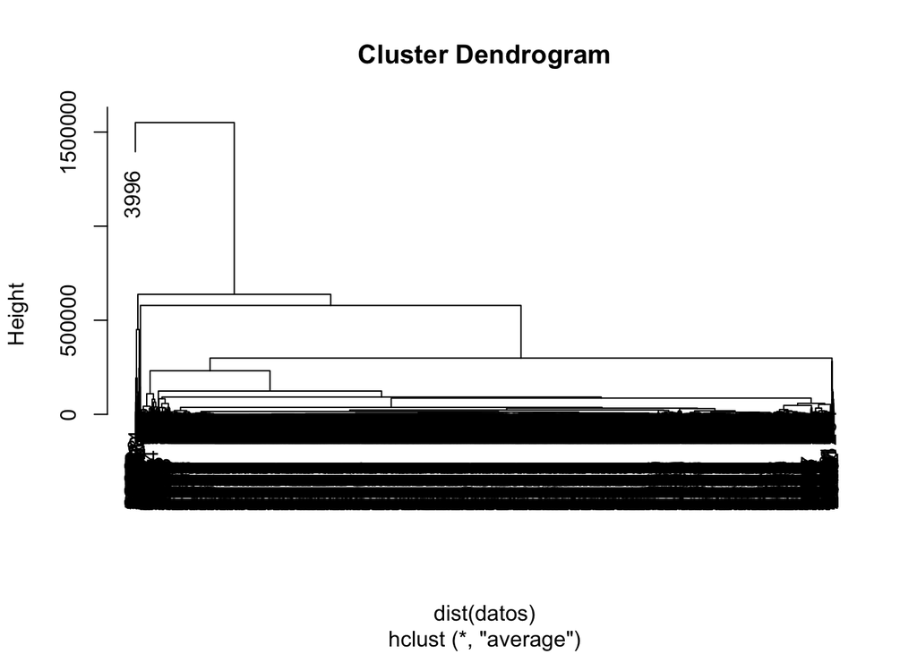

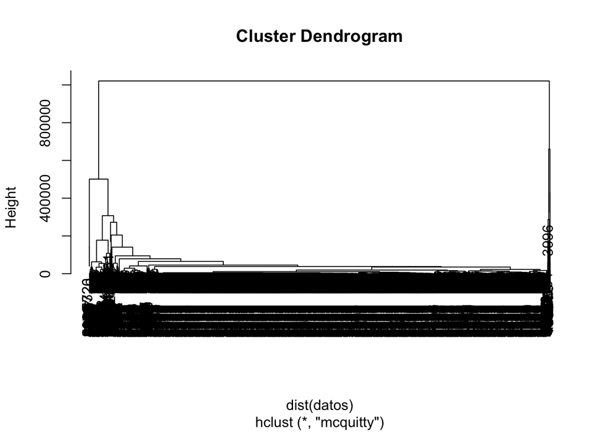

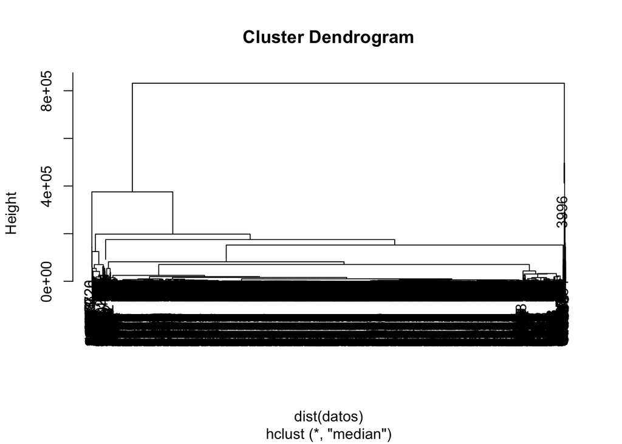

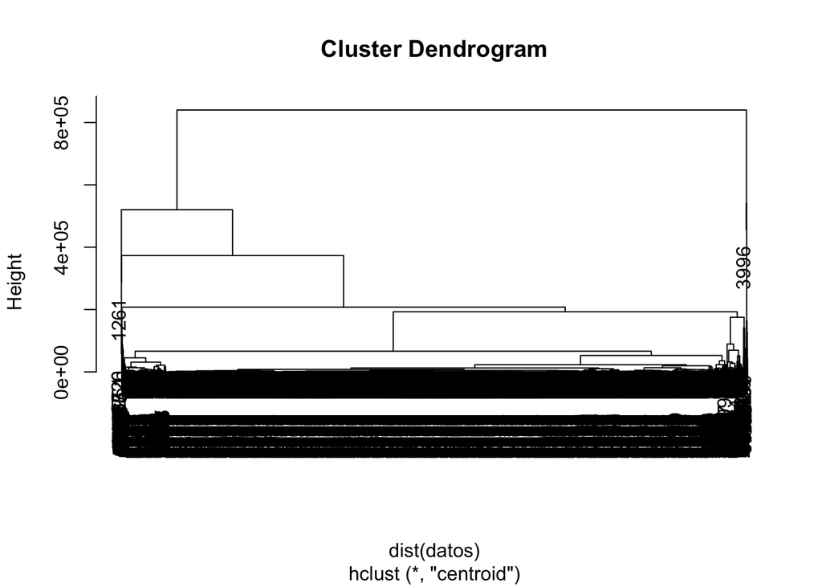

```r
library("FactoMineR")
library("factoextra")

metodos <- c("ward.D", "ward.D2", "single", "complete", "average", "mcquitty", "median",
    "centroid")

# Creación de los nodos
version.snow <- function(datos) {

    peones <- parallel::detectCores()
    clp <- makeCluster(peones, type = "SOCK")

    # Constructor del cluster
    ignore <- clusterExport(clp, "datos")

    metodos <- c("ward.D", "ward.D2", "single", "complete", "average", "mcquitty",
        "median", "centroid")


    resultado <- clusterApply(clp, metodos, function(metodo) {

        library("FactoMineR")
        library("factoextra")

        modelo <- hclust(dist(datos), method = metodo)


    })


    return(resultado)
}


modelos <- version.snow(datos)

for (i in modelos) {
    plot(i)
}
```

## b) Desarrolle una función que reciba un `data.frame` y una variable que contenga a que grupo pertenece cada individuo y retorna la inercia intra-clase, puede usar como referencia el archivo de excel `EjemploEstudiantesKmeans.xls`.

```r
inercia.intra.clase <- function(datos, grupos) {

    cantidad <- dim(datos)[1]
    tabla <- cbind(datos, grupos)

    centros <- lapply(1:length(unique(grupos)), function(i) {
        apply(tabla[tabla$grupos == i, ], 2, mean)
    })

    inercias <- sapply(1:length(centros), function(i) {
        # sum((tabla[tabla$grupos == i,]- centros[[i]])^2)

        suma <- 0

        for (j in 1:(ncol(tabla) - 1)) {
            suma <- suma + sum((tabla[tabla$grupos == i, j] - centros[[i]][j])^2)
        }
        suma
    })

    return(sum(inercias))
}
```

## d) Usando el criterio de la **Inercia Intra-Clases** y **usando 2 clústeres** determine cuál de los 8 métodos es mejor, se entiende como el mejor aquel cluster con la menor **Inercia Intra-Clases**.

```r
grupos <- lapply(modelos, cutree, k = 2)

grupos
```

[output not shown]

```r
inercias <- sapply(grupos, inercia.intra.clase, datos = datos)

names(inercias) <- metodos

inercias[inercias == min(inercias)]
```

```
     ward.D2
1.943902e+13
```

# 3. Usando nuevamente la tabla de datos `ChurnTelecom6k.csv` realice lo siguiente:

```r
datos <- read.table("Datos Tarea/ChurnTelecom6K.csv", sep = ",", dec = ".", header = TRUE,
    stringsAsFactors = TRUE)
```

## a) Realice la predicción para la variable `Churn` utilizando los métodos de `bosques aleatorios, XGBoost` y `Redes Neuronales` de H2O.

```r
library(h2o)
library(traineR)

h2o.init()
```

[output not shown]

```r
datos <- h2o.importFile(path = "Datos Tarea/ChurnTelecom6K.csv")
# partición de los datos
muestras <- h2o.splitFrame(data = datos, ratios = 0.75)

aprendizaje <- muestras[[1]]
prueba <- muestras[[2]]
```

### Bosques aleatorios

```r
modelo <- h2o.randomForest(y = "Churn", training_frame = aprendizaje, nfolds = 5,
    ntrees = 10, max_depth = 2)
prediccion <- h2o.predict(modelo, prueba)
# matriz de confusión

real <- as.vector(prueba[, "Churn"])
ref <- as.vector(prediccion[, 1])
mc <- table(real, ref)

general.indexes(mc = mc)
```

```
Confusion Matrix:
     ref
real   No Yes
  No  277 769
  Yes  63 375

Overall Accuracy: 0.4394
Overall Error:    0.5606

Category Accuracy:

           No          Yes
     0.264818     0.856164
```

### Redes Neuronales

```r
modelo <- h2o.deeplearning(y = "Churn", training_frame = aprendizaje, activation = "Tanh",
    hidden = c(200, 450, 50, 25))
prediccion <- predict(modelo, prueba)
real <- as.vector(prueba[, "Churn"])
ref <- as.vector(prediccion[, 1])
mc <- table(real, ref)

general.indexes(mc = mc)
```

```
Confusion Matrix:
     ref
real   No Yes
  No  494 552
  Yes 155 283

Overall Accuracy: 0.5236
Overall Error:    0.4764

Category Accuracy:

           No          Yes
     0.472275     0.646119
```

### XGBoost

```r
modelo <- h2o.xgboost(y = "Churn", training_frame = aprendizaje, ntrees = 400, learn_rate = 0.1,
    max_depth = 2, booster = "gbtree")
prediccion <- predict(modelo, prueba)
real <- as.vector(prueba[, "Churn"])
ref <- as.vector(prediccion[, 1])
mc <- table(real, ref)

general.indexes(mc = mc)
```

```
Confusion Matrix:
     ref
real   No Yes
  No  803 243
  Yes 260 178

Overall Accuracy: 0.6611
Overall Error:    0.3389

Category Accuracy:

           No          Yes
     0.767686     0.406393
```

## b) Para cada uno de los modelos anteriores construya la matriz de confusión y calcule la precisión global y por clase.

Resuelto en el punto anterior.